# 結晶データの解析、特にvolume-optimal cycleとtightened-volumeについて

この文章では3x3の立方格子のデータを解析します。 完全な立方格子ではなく、ノイズが加えたデータを解析します。ここでは1次のパーシステント図を解析します。

まず、パーシステント図を計算します。

```bash
python3 -m homcloud.pc_alpha -D -I -d 3 --no-square cubic_crystal.txt cubic_crystal.idiagram
```

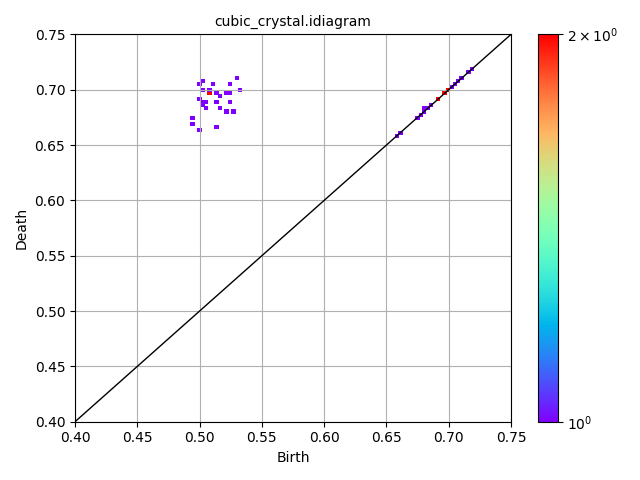

```bash
python3 -m homcloud.plot_PD -d 1 -x 0.4:0.75 -l cubic_crystal.idiagram -o cubic_crystal_PD1.png
display < cubic_crystal_PD1.png
```

birth が0.5, death 0.7のあたりに点が集中しています。これは立方格子内の一辺の長さ1の正方形が作るリングが対応しています。

birth は 1 の 1/2 の 0.5、death は $\sqrt{2}$ (正方形の対角線の長さ) の 1/2 の 0.70.. が対応しています。ノイズを加えている分だけ birth-death pairが拡散しています。

次にこのbirth-death pairに対応するリングをvolume-optimal cycle (optimal volume)を使って計算しましょう。まずすべての birth-death pairを表示します。

```bash
python3 -m homcloud.dump_diagram -d 1 cubic_crystal.idiagram -S no
```

```
0.6586306291340102 0.6590304640137213
0.6606323646333819 0.6619347226903082
0.49987336207987887 0.662713673181348
0.5121519314069597 0.6679225189216541
0.4949660182760674 0.66821394735721
0.6745095199109901 0.6753672748153773
0.49455004783609063 0.6761439650496468
0.6776483958747631 0.6776602955543044
0.6793140020774003 0.6803759145663727
0.5269822633697324 0.6804175382521039
0.5206692998733057 0.6811089887096261
0.505786855468919 0.6832301479748247
0.6807788542625179 0.683299330068848
0.5165543624337156 0.6836012939071158
0.6838155374761266 0.6838686796750284
0.6858197481159733 0.685876455603243
0.502928397276293 0.6868370231473592
0.506101119739788 0.6876344979407797
0.5147215515974617 0.6880312826094712
0.5252097936511079 0.6890763453976236
0.5025608575422964 0.689171867637253
0.5002435126147523 0.6899910037142132
0.6911565942161753 0.6915995803753984
0.6918926113623273 0.6922603105982803
0.5159753174844722 0.6937171904705405
0.5138802936339488 0.6964370646579495
0.6966110684017212 0.6966252119546423
0.6967433149222299 0.6967481686187554
0.5229799688832133 0.6967755570967225
0.5232724066175749 0.6968997411234836
0.5089799004945281 0.6970068037470473
0.5091621008021502 0.6975775524547941
0.5313802366272908 0.6984609668496734
0.6988049641938592 0.6988176064188562
0.5032343340877725 0.6989326288595414
0.6993780174841242 0.6998033875223009
0.5081893902733595 0.7000438469847382
0.7027127347365761 0.7034988904024337
0.5116284154743329 0.7046639222598844
0.7049844105242548 0.705513351996927
0.4995262316670215 0.7058238604707324
0.5250775786934011 0.7060074425166796
0.7064991107095185 0.7064997938645462
0.5031998471791083 0.7066449404741557
0.7101245900928161 0.7107039627866103
0.5301676220667683 0.7108090671584363
0.7146951713594543 0.7149224052333442
0.7175576975195354 0.7175926315987486
0.829719780053145 0.8297204044849945
0.8360632560378511 0.8360867659314453
0.8398918503065594 0.840147718112467
```

(0.5206692998733057, 0.6811089887096261) という pair のvolume-optimal cycleを計算します。まずは paraview で表示させます。

```bash
python3 -m homcloud.optimal_volume -d 1 -x 0.5206692998733057 -y 0.6811089887096261 -P cubic_crystal.idiagram
```

この場合には正方形が現れます。実際に頂点を表示しましょう。`voc-1.json`に保存して、`jq`というプログラムで情報を切り出します。

```bash
python3 -m homcloud.optimal_volume -d 1 -x 0.5206692998733057 -y 0.6811089887096261 -j voc-1.json cubic_crystal.idiagram
jq -r '.result[0]."boundary-points"[] | @tsv'  < voc-1.json
```

```
-0.022255800483552014	0.023659139352163072	0.9768963895898605
0.04563001802111903	-0.022869567479032318	1.9533706361668377
-0.03087908081352836	0.9643067747567892	1.0279201400018765
-0.042979431936026984	1.0133969245072298	2.0051992217833803
```

(0,0,1), (0,0,2), (0,1,1), (0,1,2) という4点からなっていることがわかります。

(0.5091621008021502, 0.6975775524547941) という pair に対しても同様の解析をします。

```bash
# 可視化
python3 -m homcloud.optimal_volume -d 1 -x 0.5091621008021502 -y 0.6975775524547941 -P cubic_crystal.idiagram
```

```bash
# 頂点を計算
python3 -m homcloud.optimal_volume -d 1 -x 0.5091621008021502 -y 0.6975775524547941 -j voc-2.json cubic_crystal.idiagram
jq -r '.result[0]."boundary-points"[] | @tsv ' < voc-2.json
```

```
0.010981508105209217	2.045199500969634	0.036362660302841854
0.0072809064876125165	1.9604875237665966	0.9625477057099272
1.0206532366788403	1.979286245962941	0.00858106673754453
0.980187842201634	2.0335467610373645	1.0341102828474105
1.9611531711740877	1.992047898713316	0.026019232881991525
1.9544148121435598	1.9779564025826202	1.044223634673405
```

6頂点からなる長方形状のものが計算されていることがわかります。このbirth-death pairは一辺の長さ1の正方形と対応する、という話ですがこの 場合は長方形が得られます。実はパーシステントホモロジーでは複数の単位構造がくっついたものが現れることがよくあります。

ここで、この長方形はどれほど「あてになる」ものなのでしょう。つまりノイズに対しどれほど頑健なのでしょう。実のところこういった 「複数の単位構造がくっついたもの」はノイズに対して不安定です。

では、何か「ノイズに対しもっと安定なもの」がないでしょうか。HomCloudにはtightened volumeというのが実装されていて、それが使えます。

それでは tightened volume を計算しましょう。 これは `homcloud.optimal_volume` に `--tightened-volume THRESHOLD` というオプションを与えると 計算できます。

```bash
# 可視化
python3 -m homcloud.optimal_volume -d 1 -x 0.5091621008021502 -y 0.6975775524547941 --tightened-volume 0.05 \
  --no-optimal-volume on -P cubic_crystal.idiagram
```

```bash
# 頂点を表示
python3 -m homcloud.optimal_volume -d 1 -x 0.5091621008021502 -y 0.6975775524547941 --tightened-volume 0.05 \
  --no-optimal-volume on -j tv-2.json cubic_crystal.idiagram
jq -r '.result[0]."tightened-volume"."boundary-points"[] | @tsv ' < tv-2.json
```

```
0.980187842201634	2.0335467610373645	1.0341102828474105
1.9544148121435598	1.9779564025826202	1.044223634673405
1.9611531711740877	1.992047898713316	0.026019232881991525
1.0206532366788403	1.979286245962941	0.00858106673754453
```

この解析では volume-optimal cycleは計算する必要はないので、`--no-optimal-volume on`を付けることで計算を省略します。 すると確かに4頂点の正方形が得られています。

最後に、(0.5, 0.7) の周りにあるbirht-daeth pairすべてに対してvolume-optimal cycleとtightened-volumeを比較しましょう。 `-X "[0.45:0.55]" -Y "[0.65:0.75]"` と指定することで、この範囲にあるものすべてを対象に計算します。

```bash
python3 -m homcloud.optimal_volume -d 1 -X "[0.45:0.55]" -Y "[0.65:0.75]" -j voc-all.json cubic_crystal.idiagram
```

ここでは各cycleの頂点の個数だけ表示します。`jq`の機能を使って数えます。

```bash
jq  '.result[]."boundary-points" | length'  < voc-all.json
```

```
4
4
4
4
4
4
4
4
6
4
4
4
6
6
4
4
4
4
4
6
4
4
8
6
10
6
11
6
```

頂点が4個以外のものがいくつか現れているのがわかります。

次にtightened volumeを使ってみます。

```bash
python3 -m homcloud.optimal_volume -d 1 -X "[0.45:0.55]" -Y "[0.65:0.75]" --tightened-volume 0.05 \
  --no-optimal-volume on -j tv-all.json cubic_crystal.idiagram
```

```bash
jq  '.result[]."tightened-volume"."boundary-points" | length'  < tv-all.json
```

```
4
4
4
4
4
4
4
4
4
4
4
4
4
4
4
4
4
4
4
4
4
4
4
4
4
4
4
4
```

すべての頂点数が4となっています。期待通りの結果といえます。

## Note

optimal volume というのは volume-optimal cycleの内側の領域のことです。実際のところ計算しているのは optimal volumeでvolume-optimal cycleはその境界を取っています。

`--tightened-volume` の引数の 0.05 というのは、およそ「このくらいのノイズを加えても安定な情報を調べる」ということを 意味しています。ここでは(0.5, 0.7)近辺のbirth-daeth pairの分布範囲を目安に値を決めています。

ここで使った tightened volume というものが本当に「安定な情報」を見ているのか、というのは 今のところ数学的な保証はありません。おそらく何らかの数学的な特徴付けが可能だと思いますがそれは今後の課題です。

`--tightened-volume` の他に `--tightened-subvolume`, `--owned-volume` という似たようか機能があります。 計算アルゴリズムが違うのですが得られる結果は似ています。これらはvolume-optimal cycleの計算結果を使うので `-no-optimal-volume on` は外してください。